# Graphics in R: ggplot2

## Themes

Themes are saved sets of aestheics that can be used as a basis for the visualization. Available themes are listed on the ggplot reference page: https://ggplot2.tidyverse.org/reference/

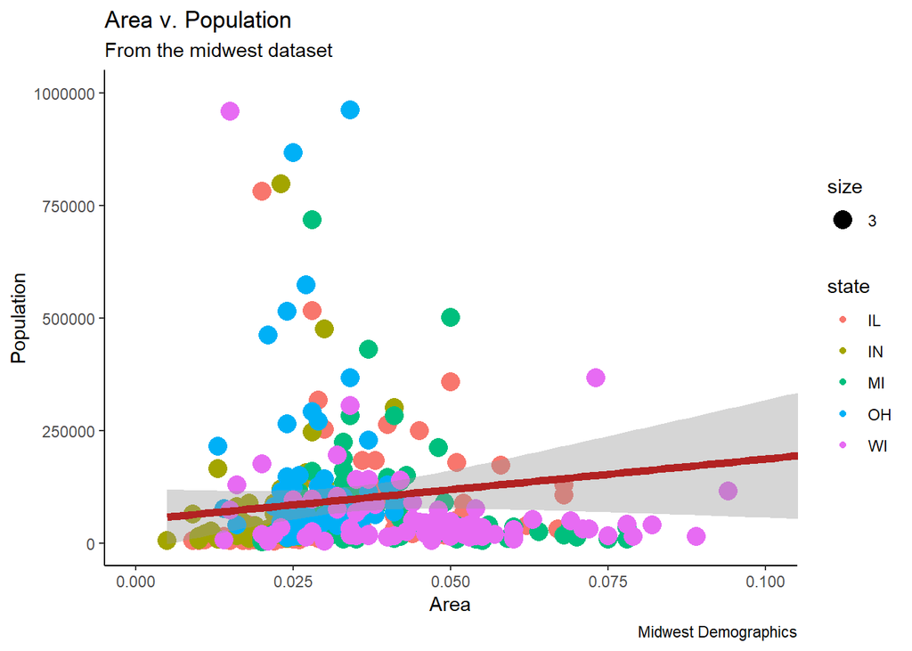

```r
theme_set(theme_classic()) # Themes can be set in the background for all visualizations to adopt when drawn
gg
```

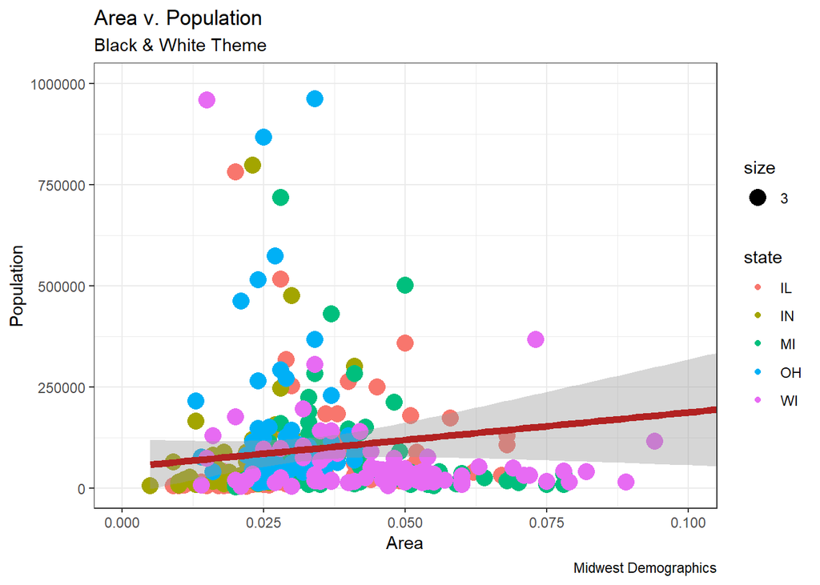

```r
gg + theme_bw() + labs(subtitle = "Black & White Theme") # Or Themes can be built into the existing visualization as a layer
```

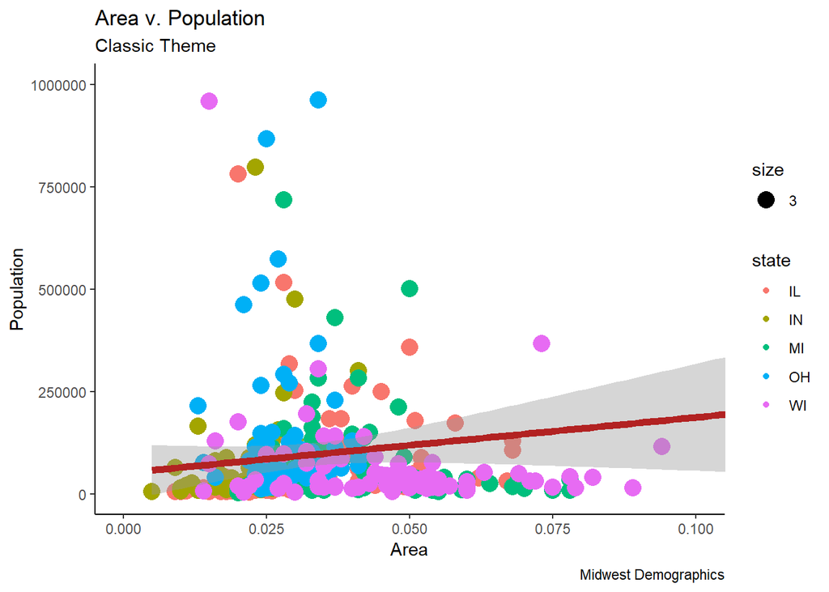

```r
gg + theme_classic() + labs(subtitle = "Classic Theme")
```

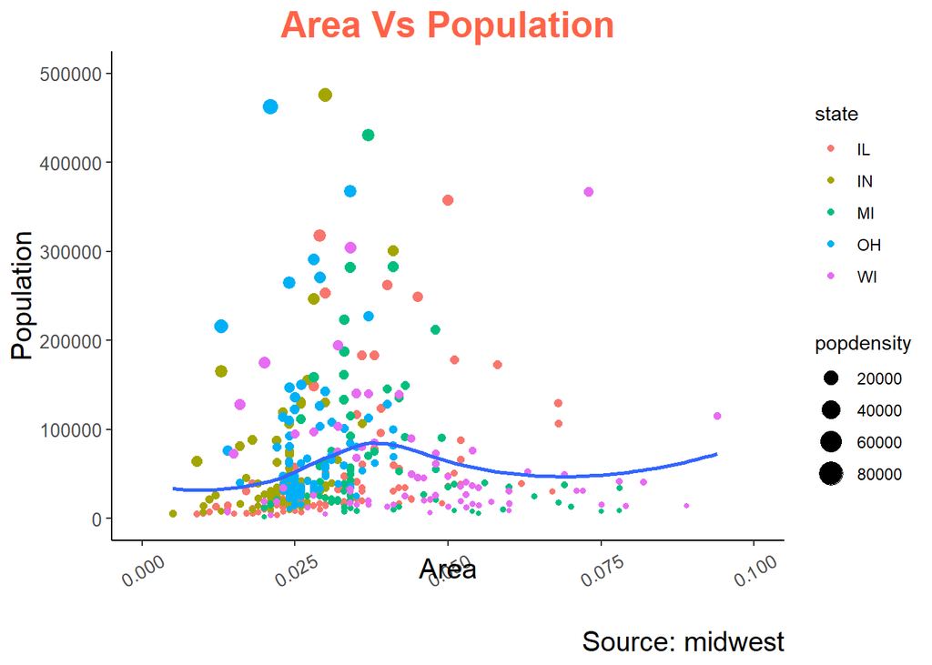

```r
gg <- ggplot(midwest, aes(x=area, y=poptotal)) +
  geom_point(aes(col=state, size=popdensity)) +
  geom_smooth(method="loess", se=F) + xlim(c(0, 0.1)) + ylim(c(0, 500000)) +
  labs(title="Area Vs Population", y="Population", x="Area", caption="Source: midwest")

# Modify theme components -------------------------------------------
gg + theme(plot.title=element_text(size=20,
                                    face="bold",
                                    family="American Typewriter",
                                    color="tomato",
                                    hjust=0.5,
                                    lineheight=1.2),  # title
            plot.subtitle=element_text(size=15,
                                       family="American Typewriter",
                                       face="bold",
                                       hjust=0.5),  # subtitle
            plot.caption=element_text(size=15),  # caption
            axis.title.x=element_text(vjust=10,
                                      size=15),  # X axis title
            axis.title.y=element_text(size=15),  # Y axis title
            axis.text.x=element_text(size=10,
                                     angle = 30,
                                     vjust=.5),  # X axis text
            axis.text.y=element_text(size=10))  # Y axis text
```

**labs()** v. **guides()**

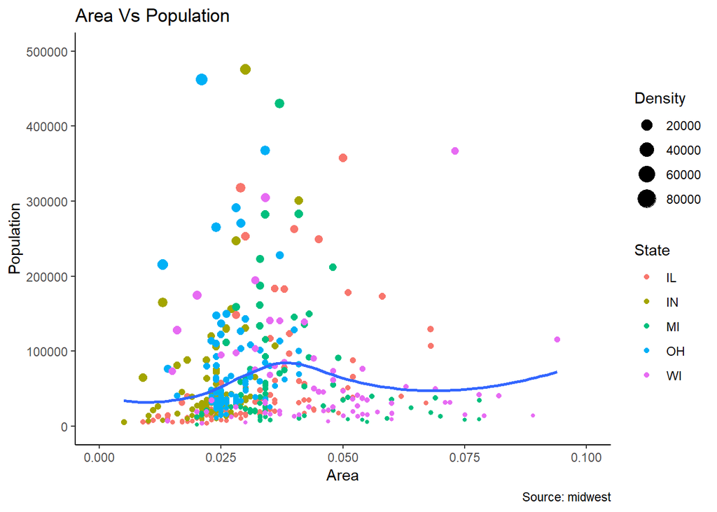

```r
gg + labs(color="State", size="Density") # labs()
```

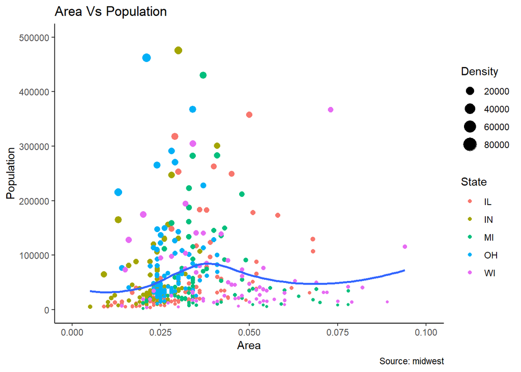

```r
gg + guides(color=guide_legend("State"), size=guide_legend("Density")) # guides()
```

Remove aesthetic from individual geometry:

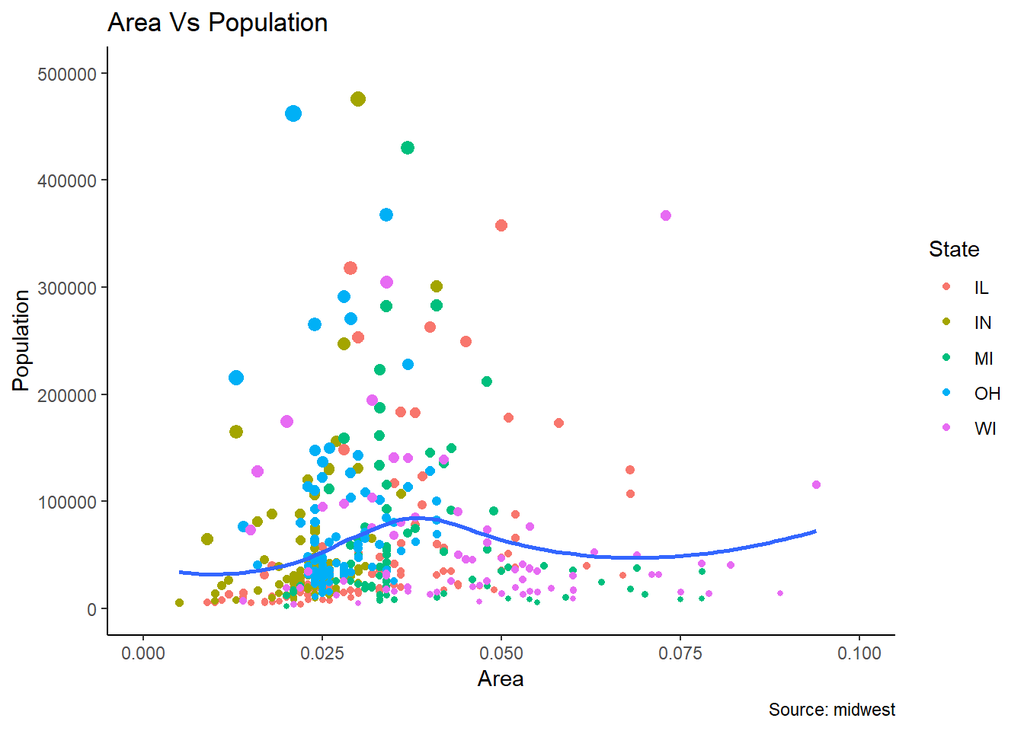

```r
gg <- ggplot(midwest, aes(x=area, y=poptotal)) +
  geom_point(aes(col=state, size=popdensity)) +
  geom_smooth(method="loess", se=F) + xlim(c(0, 0.1)) + ylim(c(0, 500000)) +
  labs(title="Area Vs Population", y="Population", x="Area", caption="Source: midwest")
gg + scale_color_discrete(name = "State") + scale_size_continuous(name = "Density", guide = FALSE) # The aestheic color was given the variable type 'state' and the aestheic size was given the variable type 'popdensity' in geom_point() and can be controlled with the layer object 'scale_<aesthetic>_<variabletype>': turn off legened with 'guide' option
```

Control individual elements of the labels with **scale_color_manual**:

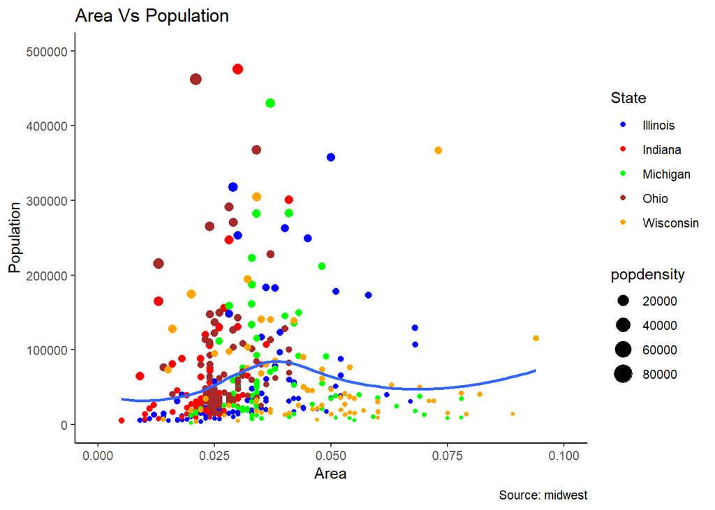

```r
gg + scale_color_manual(name="State",
                        labels = c("Illinois",
                                   "Indiana",
                                   "Michigan",
                                   "Ohio",
                                   "Wisconsin"),
                        values = c("IL"="blue",
                                   "IN"="red",
                                   "MI"="green",
                                   "OH"="brown",
                                   "WI"="orange"))
```

Use **guides()** to order the legend:

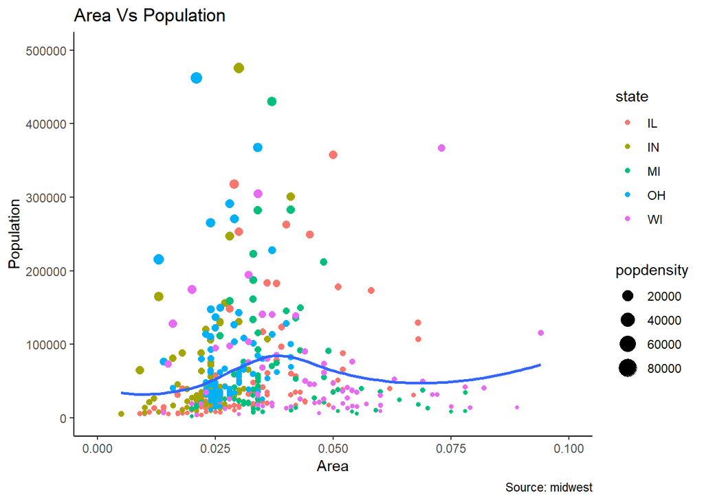

```r
gg + guides(colour = guide_legend(order = 1), size = guide_legend(order = 2))
```

**element_rect()** controls figure like elements, i.e. the legend:

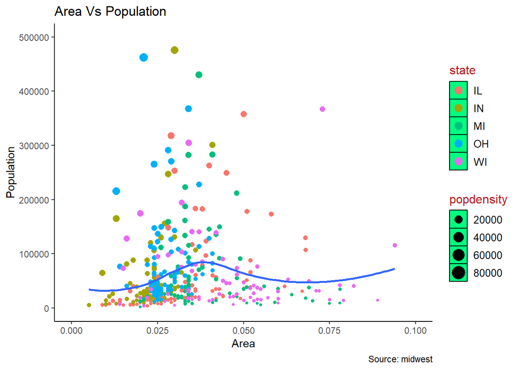

```r
gg + theme(legend.title = element_text(size=12, color = "firebrick"),
           legend.text = element_text(size=10),
           legend.key = element_rect(fill='springgreen')) + # Fill the legend key background with element_rect()
  guides(colour = guide_legend(override.aes = list(size=2, stroke=1.5)))
```

Use **theme()** to change position and orientation of legend:

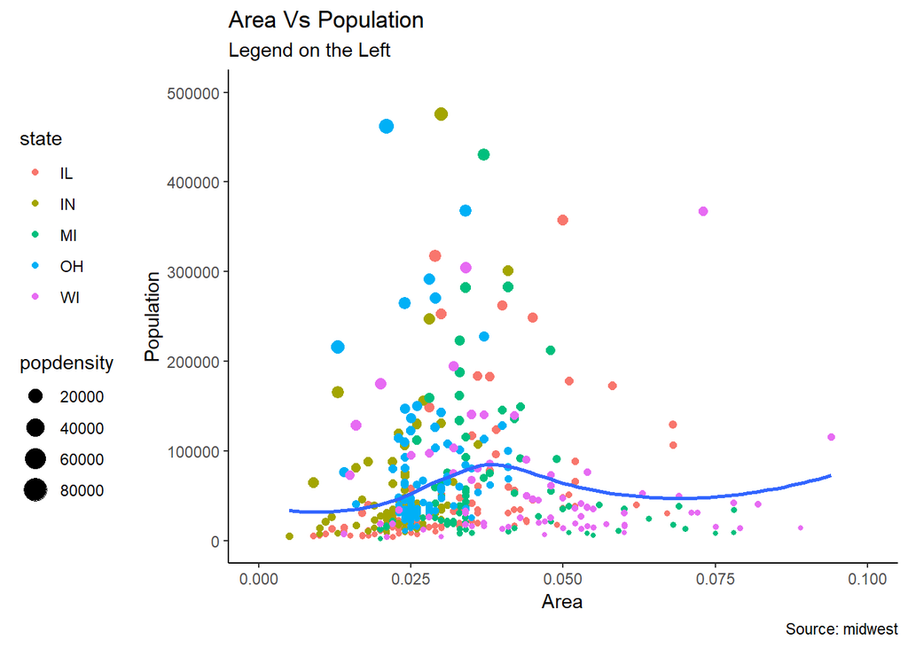

```r
gg + theme(legend.position="left") + labs(subtitle="Legend on the Left")
```

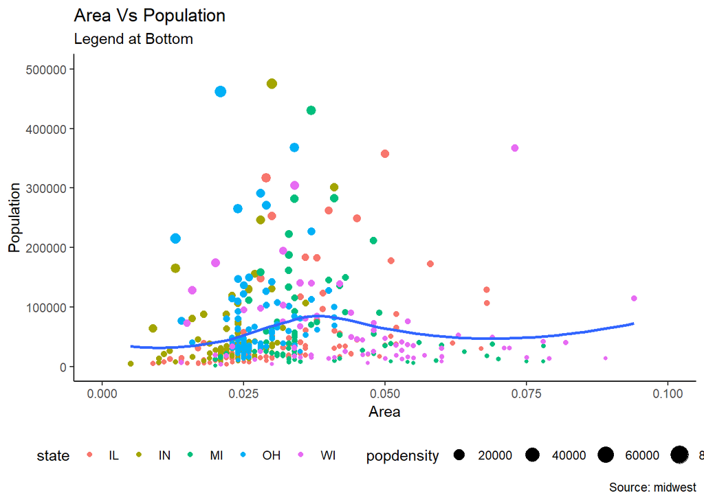

```r
gg + theme(legend.position="bottom", legend.box = "horizontal") + labs(subtitle="Legend at Bottom")
```

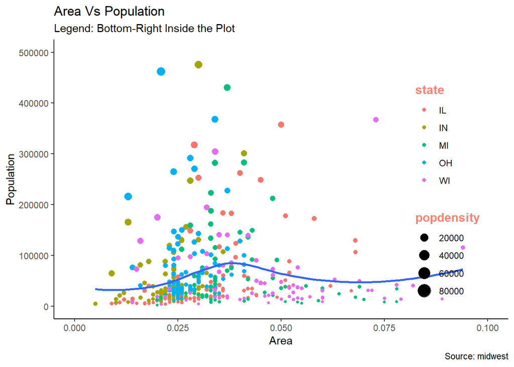

```r
gg + theme(legend.title = element_text(size=12, color = "salmon", face="bold"),
           legend.justification=c(1,0),
           legend.position=c(0.95, 0.05),
           legend.background = element_blank(),
           legend.key = element_blank()) +
  labs(subtitle="Legend: Bottom-Right Inside the Plot")
```

## Annotations

Rules for annotation must be included in a dataset derived or compatible with the data frame originally used to set up ggplot:

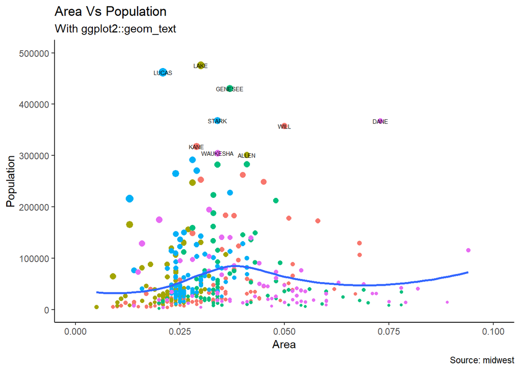

```r
midwest_sub <- midwest[midwest$poptotal > 300000, ] # Subset data frame 'midwest' for large populations
midwest_sub$large_county <- ifelse(midwest_sub$poptotal > 300000, midwest_sub$county, "") # Create column with labels for annotations
gg + geom_text(aes(label=large_county), size=2, data=midwest_sub) + labs(subtitle="With ggplot2::geom_text") + theme(legend.position = "None")
```

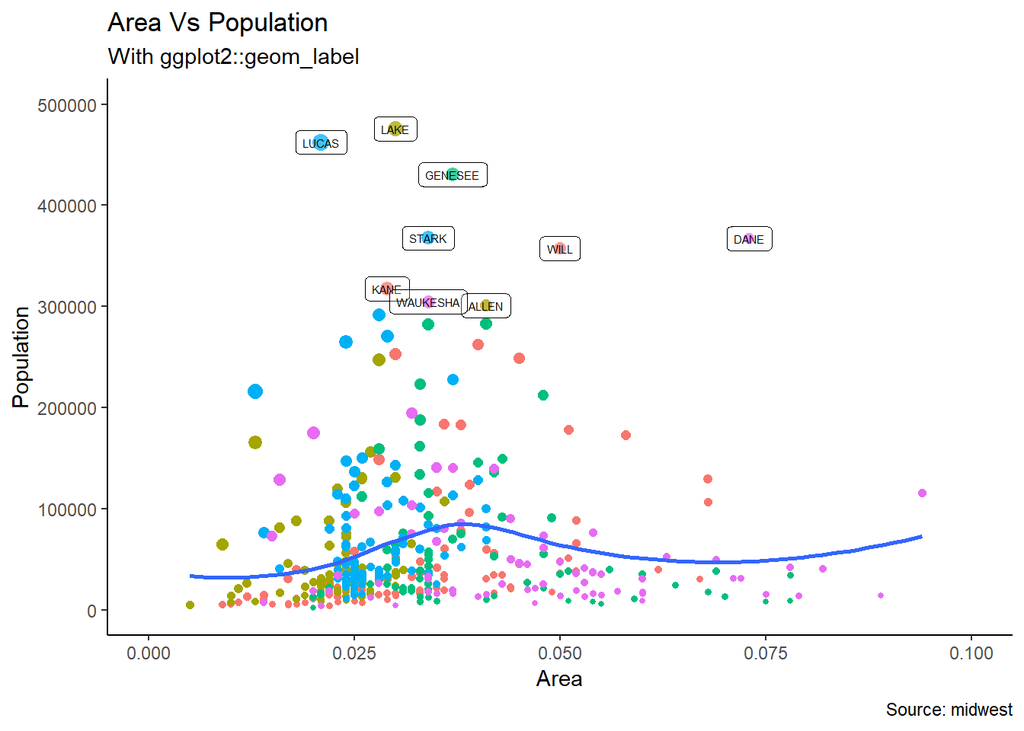

```r
gg + geom_label(aes(label=large_county), size=2, data=midwest_sub, alpha=0.25) + labs(subtitle="With ggplot2::geom_label") + theme(legend.position = "None")
```

```r
# library(ggrepel) will push annotations away from one another for a cleaner look
```

Add text to plot based on coordinates:

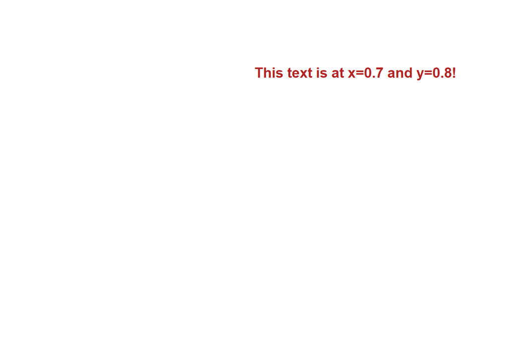

```r
library(grid) # graphics package that adds an nx by ny rectanglular grid to an existing plot
my_text <- "This text is at x=0.7 and y=0.8!"
my_grob = grid.text(my_text, x=0.7,  y=0.8, gp=gpar(col="firebrick", fontsize=14, fontface="bold"))
```

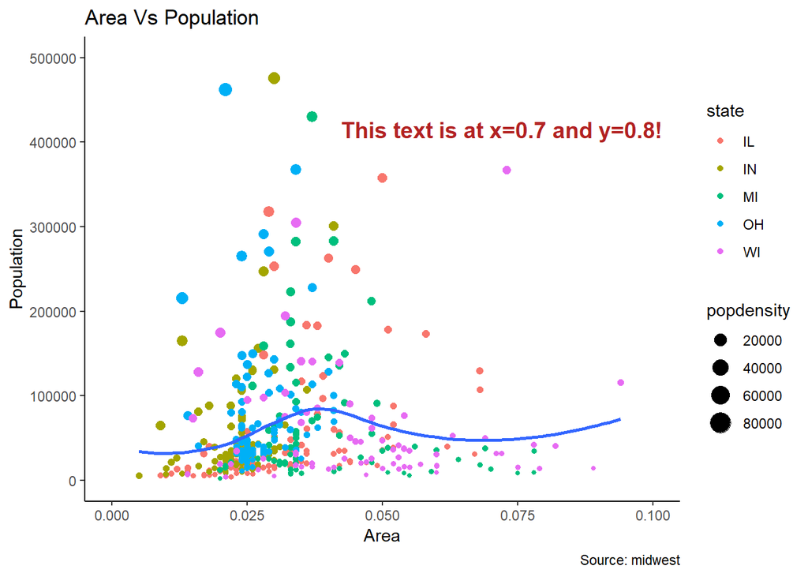

```r
gg + annotation_custom(my_grob)
```

## Flip Coordinates

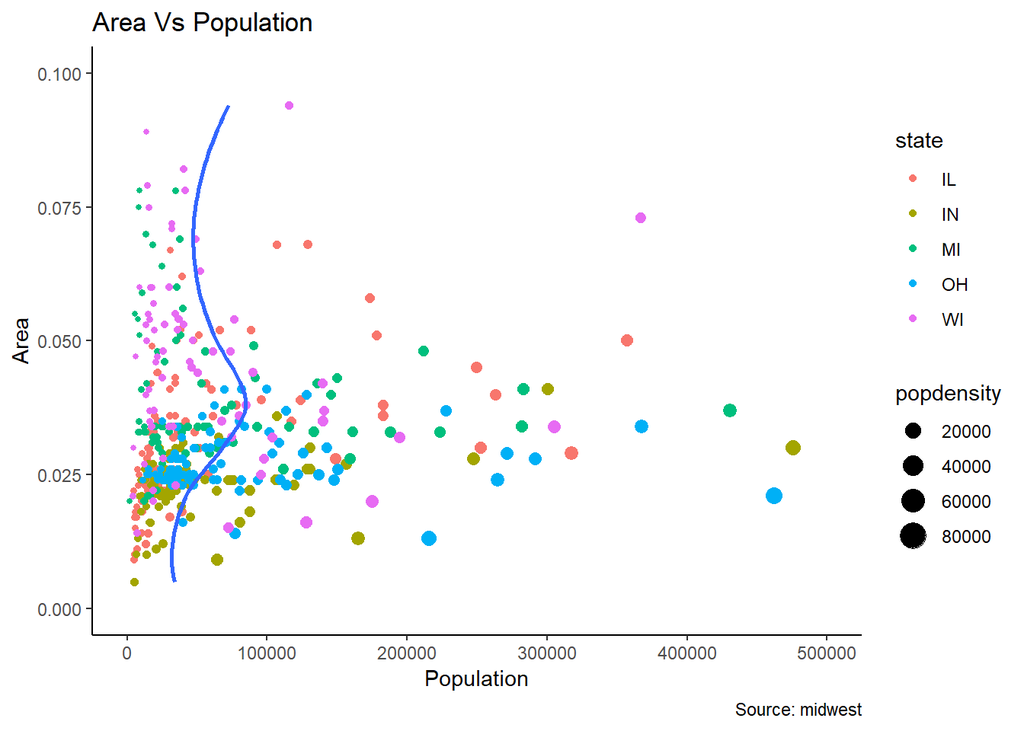

```r
gg + coord_flip()
```

## Faceting

Draw multiple plots on one figure (new data set):

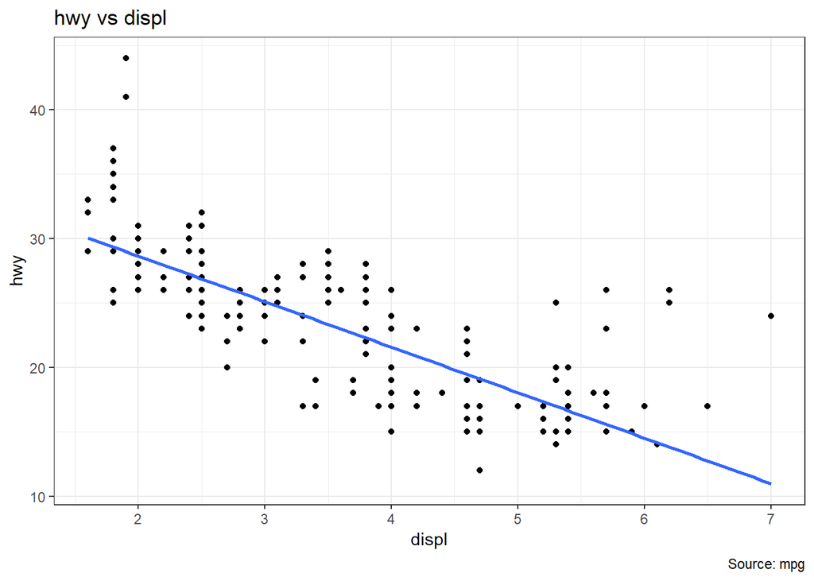

```r
data(mpg, package = 'ggplot2')

g <- ggplot(mpg, aes(x=displ, y=hwy)) +
      geom_point() +
      labs(title="hwy vs displ", caption = "Source: mpg") +
      geom_smooth(method="lm", se=FALSE) +
      theme_bw()  # apply bw theme
plot(g)
```

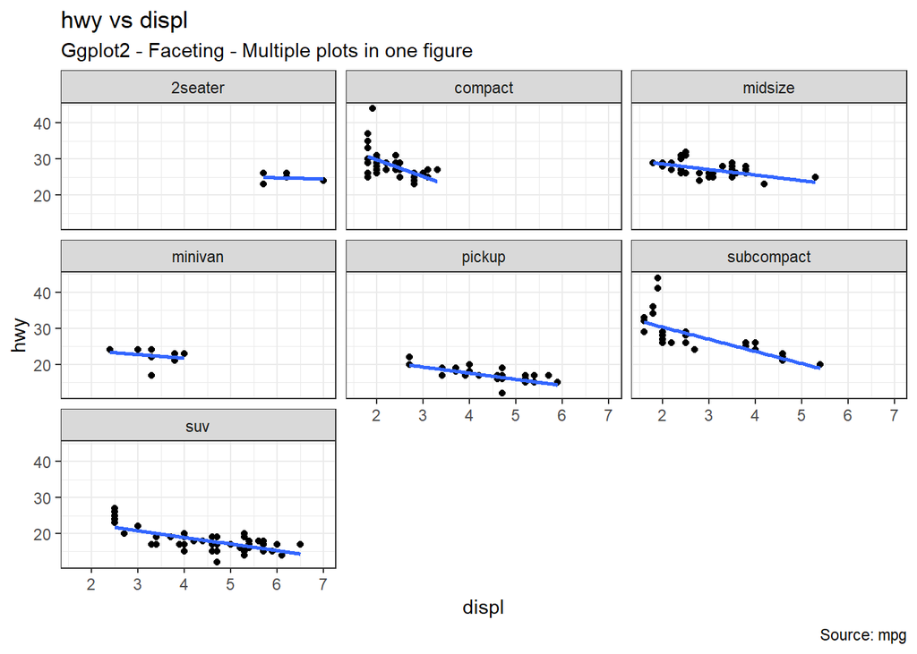

```r
g + facet_wrap( ~ class, nrow=3) + labs(title="hwy vs displ", caption = "Source: mpg", subtitle="Ggplot2 - Faceting - Multiple plots in one figure")
```

By deafault, the scales for each plot are the same. They can become ‘freed’ for individaul scales for each plot:

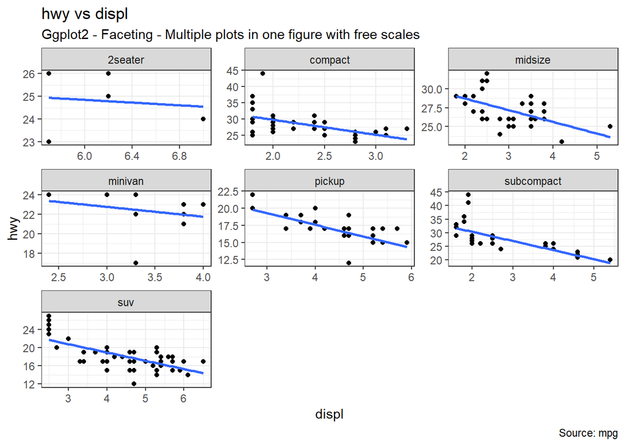

```r
g + facet_wrap( ~ class, scales = "free") + labs(title="hwy vs displ", caption = "Source: mpg", subtitle="Ggplot2 - Faceting - Multiple plots in one figure with free scales")
```

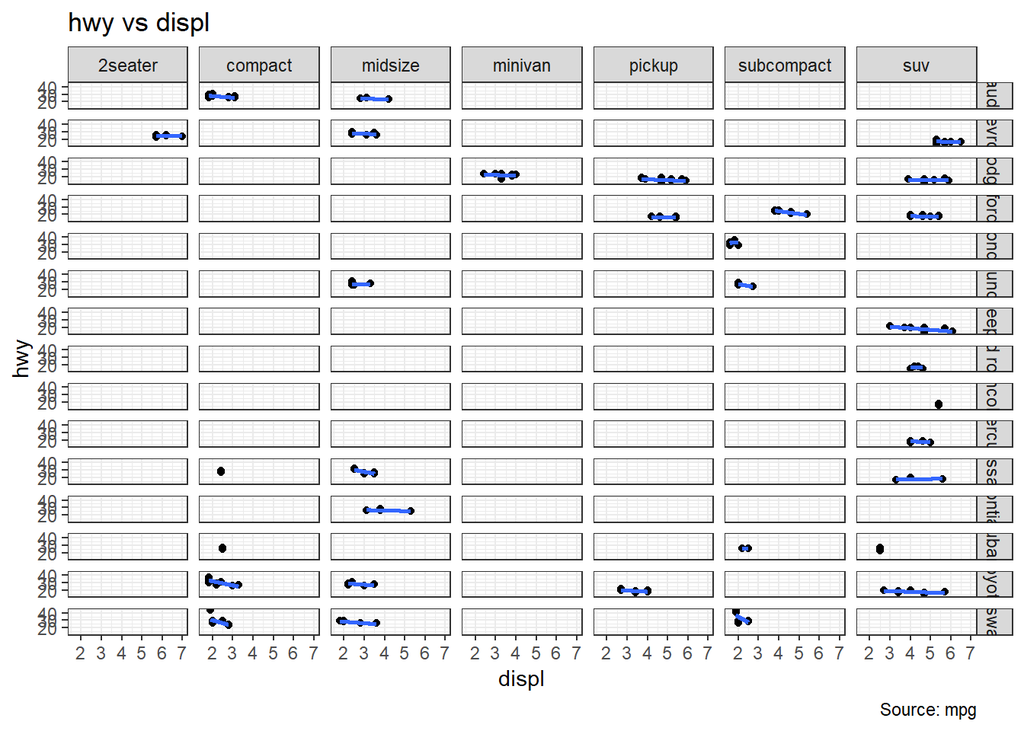

```r
g + facet_grid(manufacturer ~ class) # Set manufacturer as rows and class as columns
```

- library(gridExtra) will allow you to wrap facets within facets

## Plot Features: Background, Major/Minor Axes

Using the theme option **panel** gives us control over the many plot features:

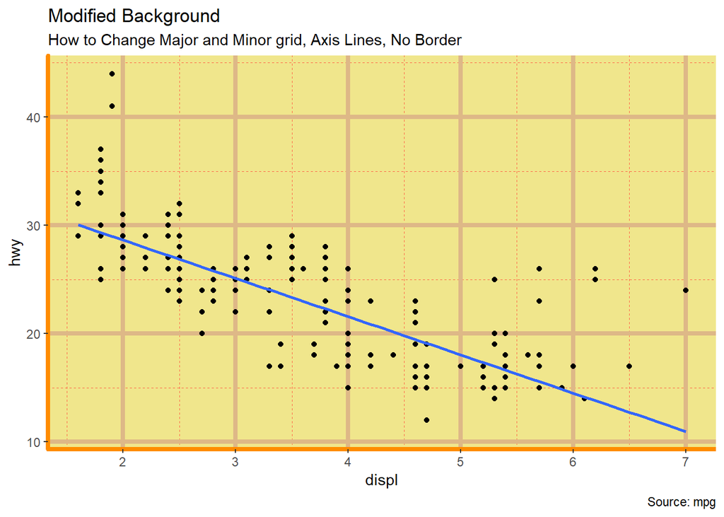

```r
g + theme(panel.background = element_rect(fill = 'khaki'),
          panel.grid.major = element_line(colour = "burlywood", size=1.5),
          panel.grid.minor = element_line(colour = "tomato",
                                          size=.25,
                                          linetype = "dashed"),
          panel.border = element_blank(),
          axis.line.x = element_line(colour = "darkorange",
                                     size=1.5,
                                     lineend = "butt"),
          axis.line.y = element_line(colour = "darkorange",
                                     size=1.5)) +
    labs(title="Modified Background",
         subtitle="How to Change Major and Minor grid, Axis Lines, No Border")
```

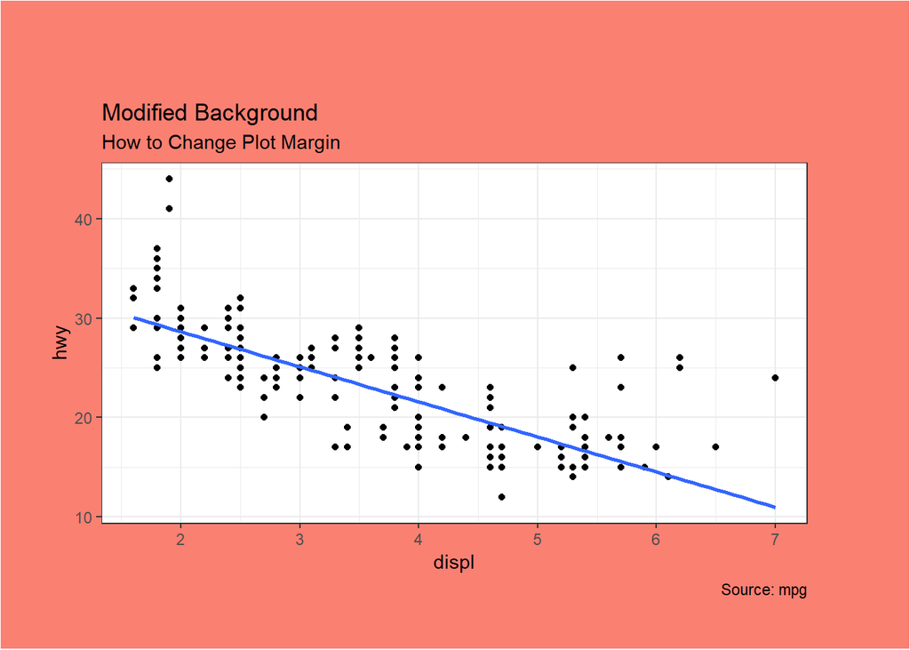

```r
# Change Plot Margins -----------------------------------------------
g + theme(plot.background=element_rect(fill="salmon"),
          plot.margin = unit(c(2, 2, 1, 1), "cm")) +  # top, right, bottom, left
    labs(title="Modified Background", subtitle="How to Change Plot Margin")
```

Remove everything!

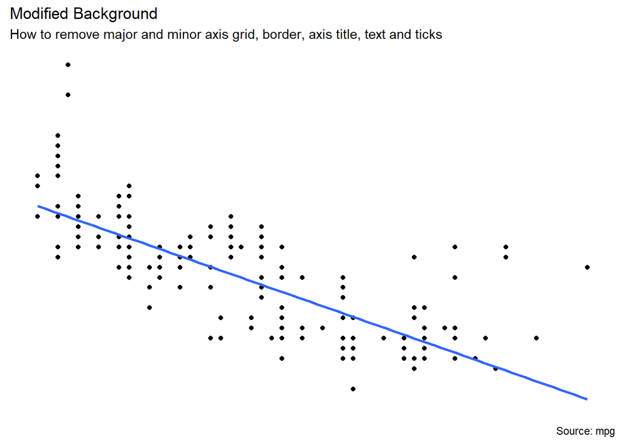

```r
g + theme(panel.grid.major = element_blank(),
          panel.grid.minor = element_blank(),
          panel.border = element_blank(),
          axis.title = element_blank(),
          axis.text = element_blank(),
          axis.ticks = element_blank()) +
  labs(title="Modified Background", subtitle="How to remove major and minor axis grid, border, axis title, text and ticks")
```

## Additional ggplot2 Packages

There are many pacakges that follow ggplot2 grammar to be used to enhance ggplot2 visualizations:

- library(ggthemes)
- library(ggthemr)
- library(ggalt)
- library(gganimate)
- library(ggExtra)
- library(ggcorrplot)
- library(scales)
- library(gridExtra)

## ggplot2 Walkthroughs/Guides

- r-statistics.co Short Tutorial & Tutorials 1,2,3: http://r-statistics.co/ggplot2-Tutorial-With-R.html#6.%20Commonly%20Used%20Features
- A Simple Introduction to the Graphing Philosophy of ggplot2: https://tomhopper.me/2014/03/28/a-simple-introduction-to-the-graphing-philosophy-of-ggplot2/
- Getting Started with Data Visualization in R using ggplot2: http://www.storybench.org/getting-started-data-visualization-r-using-ggplot2/